# Food Inspection in Chicago_Robin Ye

Rongbin_Ye

1/21/2020

# *Why Inspection Prediction? Public, Private, Commercial Good*

As a gourmet, one of the largest concerns is the food security. From a macro perspective, both different facility owners and inspectors would love to know the result of their inspection so they can prepare appropriate resources for additional work or improvement.

1. Demand:
- People want to have decent, clean food
- Facilities’ owners
- inspectors at Chicago City
2. Function:
- Show location
- Dashboard control for RiskType, FacilitiesType
- Predict Outcome of Inspection

```r
library(readr)
library(tidyverse)
inspection_data <- data.table::fread('https://data.cityofchicago.org/api/views/4ijn-s7e5/rows.csv?accessType=DOWNLOAD')

length(inspection_data$`Inspection ID`)
```

[output not shown]

# *Data in Use*

The summary is as follow:

```r
  summary(main_data)
```

```
##  Results                  Risk         Latitude       Longitude
##  fail:1178   risk 1 (high)  :4713   Min.   :41.65   Min.   :-87.91
##  pass:4412   risk 2 (medium): 838   1st Qu.:41.85   1st Qu.:-87.71
##              risk 3 (low)   :  39   Median :41.89   Median :-87.67
##                                     Mean   :41.89   Mean   :-87.68
##                                     3rd Qu.:41.94   3rd Qu.:-87.63
##                                     Max.   :42.02   Max.   :-87.53
##         Ftype
##  bakery    :  96
##  catering  :  40
##  restaurant:4691
##  school    : 763
##
##
```

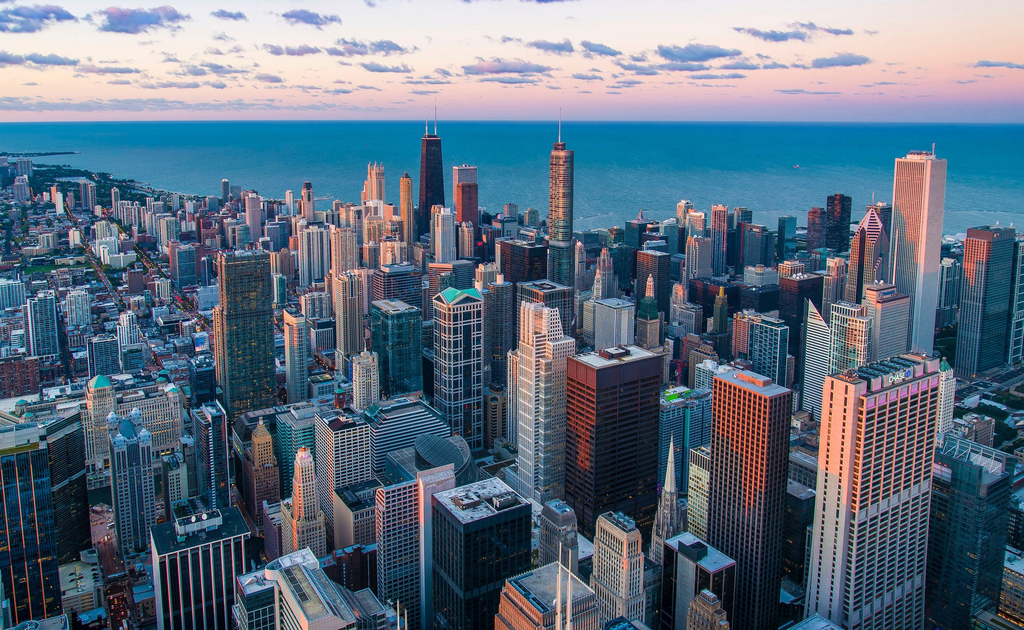

“Chicago skyline”

# *Empower Prediction by Logistic Regression*

The basic model used here is the logstic model, regarding the existing independent variables, categorical and numeric. The model summary is as follow:

```
##
## Call:
## glm(formula = Results ~ Ftype + Risk + Latitude + Longitude,
##     family = binomial, data = main_data)
##
## Deviance Residuals:
##     Min       1Q   Median       3Q      Max
## -1.8951   0.6164   0.6942   0.7014   0.8613
##
## Coefficients:
##                      Estimate Std. Error z value Pr(>|z|)
## (Intercept)         -20.85360   46.09521  -0.452  0.65098
## Ftypecatering         0.36929    0.46524   0.794  0.42734
## Ftyperestaurant       0.27524    0.24528   1.122  0.26180
## Ftypeschool           0.24201    0.26022   0.930  0.35236
## Riskrisk 2 (medium)   0.26347    0.09881   2.667  0.00766 **
## Riskrisk 3 (low)     -0.20933    0.37100  -0.564  0.57260
## Latitude             -0.24903    0.47078  -0.529  0.59682
## Longitude            -0.36843    0.57176  -0.644  0.51933
## ---
## Signif. codes:  0 '***' 0.001 '**' 0.01 '*' 0.05 '.' 0.1 ' ' 1
##
## (Dispersion parameter for binomial family taken to be 1)
##
##     Null deviance: 5756.9  on 5589  degrees of freedom
## Residual deviance: 5747.6  on 5582  degrees of freedom
## AIC: 5763.6
##
## Number of Fisher Scoring iterations: 4
```

# *Why this App?*

Before showing the real app, hereby I provide a summary of the UI elements. The sidepanel includes 4 major inputs groups.

- Longtitude & Latitude: These inputs turn into the locator.
- Ftype: This inputs provides the facility type.
- Rtype: This inputs provides the risk type.
- Show Summary: This option enable users to hide the summary.

# *Thank You & Lets try it.*

Thank You and lets try it out.

- Links as follow: “https://ronngbinye94.shinyapps.io/RY_DPDW4_noicon/”